# On the lifetime and one-year views of reserve risk, with application to IFRS 17 and Solvency II risk margins

*This code is provided by Peter England on behalf of EMC Actuarial and Analytics Ltd as an educational resource.*

R code to reproduce the tables in:

England, Verrall & Wüthrich (2018/2019). On the lifetime and one-year views of reserve risk, with application to IFRS 17 and Solvency II risk margins. **Insurance: Mathematics and Economics (2019)** https://doi.org/10.1016/j.insmatheco.2018.12.002

Pre-print version available from **SSRN (2018)** https://ssrn.com/abstract=3141239

The paper brings together analytic and simulation-based approaches to reserve risk in general (P&C) insurance, applied to the traditional actuarial view of risk over the lifetime of the liabilities and to the one-year view of Solvency II. It also connects the lifetime and one-year views of risk. Predictive distributions are used to estimate risk margins under Solvency II and risk adjustments under IFRS 17.

The code supports Mack’s model (as used in the paper), the Over-dispersed Poisson model, and the Over-dispersed Negative Binomial model.

Select which model to apply using the “method” variable below.

A commentary of the results is provided in the paper.

### Import libraries, stochastic reserving functions and data, and look at the data:

```r
# for tables
options(width=200)

## Set up libraries
suppressPackageStartupMessages(library(ggplot2))
suppressPackageStartupMessages(library(ChainLadder)) # for Merz-Wuthrich analytic SD of CDR
suppressPackageStartupMessages(library(tidyverse)) # for graphs
suppressPackageStartupMessages(library(ggfan)) # for fan charts

# Read in stochastic reserving functions
source("StochResFunctions.R")

# Read in data from csv file
TA <- read.table("TandA.csv", sep=",")

# Select triangle to work on
Triangle <- TA

# Look at data first
# Incremental claims data:
Inc_Triangle <- Incrementals(Triangle)
print("Incremental Amounts")
```

```
## [1] "Incremental Amounts"
```

```r
Inc_Triangle
```

```
##         [,1]    [,2]    [,3]    [,4]   [,5]   [,6]   [,7]   [,8]   [,9] [,10]
##  [1,] 357848  766940  610542  482940 527326 574398 146342 139950 227229 67948
##  [2,] 352118  884021  933894 1183289 445745 320996 527804 266172 425046    NA
##  [3,] 290507 1001799  926219 1016654 750816 146923 495992 280405     NA    NA
##  [4,] 310608 1108250  776189 1562400 272482 352053 206286     NA     NA    NA
##  [5,] 443160  693190  991983  769488 504851 470639     NA     NA     NA    NA
##  [6,] 396132  937085  847498  805037 705960     NA     NA     NA     NA    NA
##  [7,] 440832  847631 1131398 1063269     NA     NA     NA     NA     NA    NA
##  [8,] 359480 1061648 1443370      NA     NA     NA     NA     NA     NA    NA
##  [9,] 376686  986608      NA      NA     NA     NA     NA     NA     NA    NA
## [10,] 344014      NA      NA      NA     NA     NA     NA     NA     NA    NA
```

```r
print("Cumulative Amounts")
```

```
## [1] "Cumulative Amounts"
```

```r
#Triangle <- Cumulatives(Inc_Triangle)
Triangle
```

```
##        V1      V2      V3      V4      V5      V6      V7      V8      V9     V10
## 1  357848 1124788 1735330 2218270 2745596 3319994 3466336 3606286 3833515 3901463
## 2  352118 1236139 2170033 3353322 3799067 4120063 4647867 4914039 5339085      NA
## 3  290507 1292306 2218525 3235179 3985995 4132918 4628910 4909315      NA      NA
## 4  310608 1418858 2195047 3757447 4029929 4381982 4588268      NA      NA      NA
## 5  443160 1136350 2128333 2897821 3402672 3873311      NA      NA      NA      NA
## 6  396132 1333217 2180715 2985752 3691712      NA      NA      NA      NA      NA
## 7  440832 1288463 2419861 3483130      NA      NA      NA      NA      NA      NA
## 8  359480 1421128 2864498      NA      NA      NA      NA      NA      NA      NA
## 9  376686 1363294      NA      NA      NA      NA      NA      NA      NA      NA
## 10 344014      NA      NA      NA      NA      NA      NA      NA      NA      NA
```

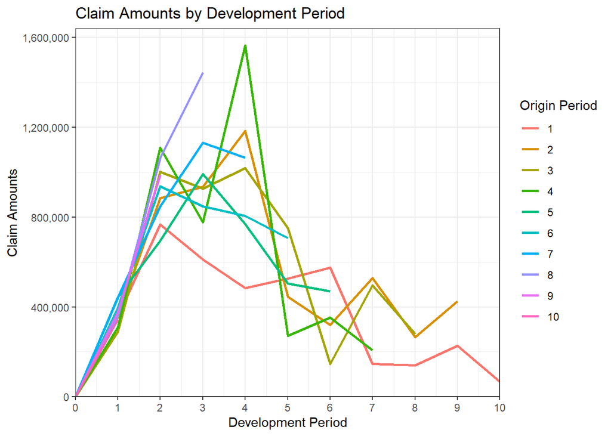

```r
# Incremental claims data:
plotTriangleGraph(Inc_Triangle)
```

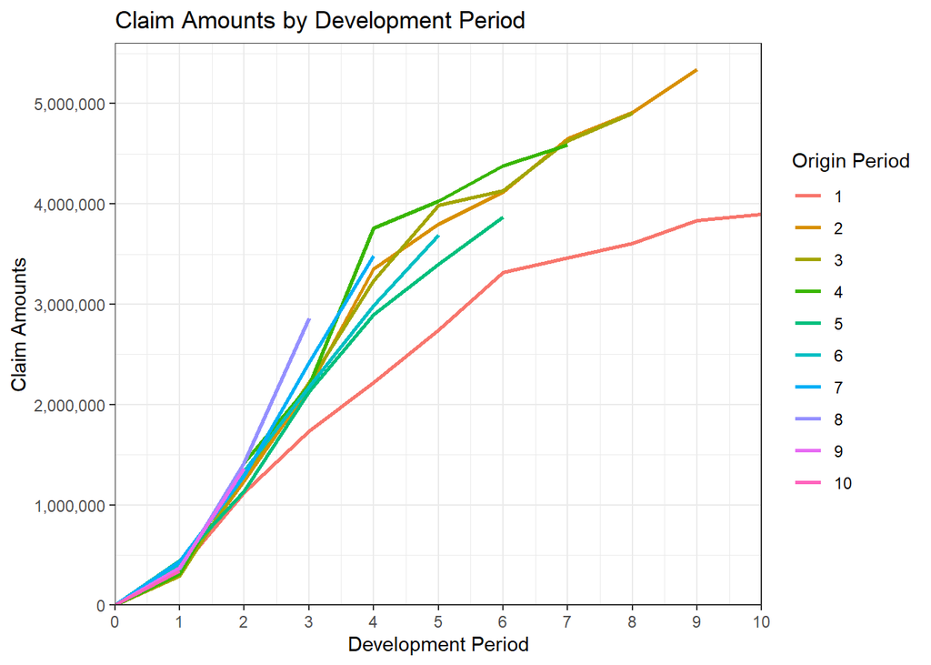

```r
# Cumulative claims data
plotTriangleGraph(Triangle)
```

```r
# Set Mask for exclusion of link ratios (if required)
Indicators <- matrix(1,nrow(Triangle)-1, ncol(Triangle)-1)
#Indicators[3,6] <- 0
```

### Obtain link ratios and volume-weighted chain ladder factors:

```r
# Calculate link ratio triangle and volume-weighted chain ladder factors
LRs <- LR_Tri(Triangle)
CL_facs <- CL_factors(LRs$LRs, LRs$Weight)

LRs$LRs
```

```
##           [,1]     [,2]     [,3]     [,4]     [,5]     [,6]     [,7]     [,8]     [,9]
##  [1,] 3.143200 1.542806 1.278299 1.237719 1.209207 1.044079 1.040374 1.063009 1.017725
##  [2,] 3.510582 1.755493 1.545286 1.132926 1.084493 1.128106 1.057268 1.086496       NA
##  [3,] 4.448450 1.716718 1.458257 1.232079 1.036860 1.120010 1.060577       NA       NA
##  [4,] 4.568002 1.547052 1.711784 1.072518 1.087360 1.047076       NA       NA       NA
##  [5,] 2.564198 1.872956 1.361545 1.174217 1.138315       NA       NA       NA       NA
##  [6,] 3.365588 1.635679 1.369162 1.236443       NA       NA       NA       NA       NA
##  [7,] 2.922798 1.878099 1.439393       NA       NA       NA       NA       NA       NA
##  [8,] 3.953288 2.015651       NA       NA       NA       NA       NA       NA       NA
##  [9,] 3.619179       NA       NA       NA       NA       NA       NA       NA       NA
```

```r
CL_facs
```

```
## [1] 3.490607 1.747333 1.457413 1.173852 1.103824 1.086269 1.053874 1.076555 1.017725
```

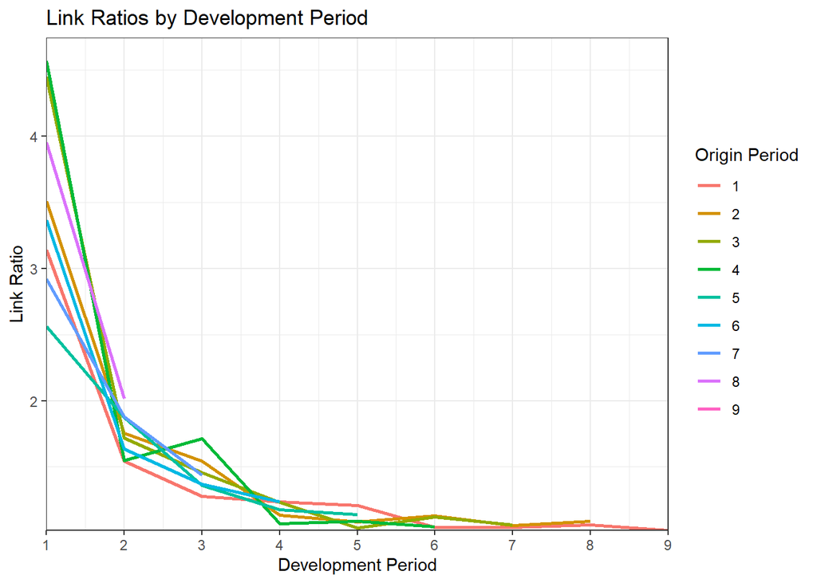

```r
#plotTriangleGraph(LRs$LRs)
plotLRsGraph(LRs$LRs)
```

### Fit a basic chain ladder model:

```r
# Calculate volume-weighted chain ladder results
CL_Result <- Tri_forecast(Triangle, CL_facs)
Latest_by_yr <- CL_Result$Latest
TotalLatest <- sum(Latest_by_yr)
Latest <- c(Latest_by_yr, TotalLatest)
Reserves_by_yr <- CL_Result$Reserves
TotalReserve <- CL_Result$TotalReserve
Reserves <- c(Reserves_by_yr, TotalReserve)
Ultimates_by_yr <- CL_Result$Ultimates
TotalUltimate <- sum(Ultimates_by_yr)
Ultimates <- c(Ultimates_by_yr, TotalUltimate)

Table_0 <- cbind(round(Latest,0), round(Reserves,0), round(Ultimates,0))
dimnames(Table_0) <- list(c(1:length(Triangle), "Total"), c("Latest", "Reserves", "Ultimates"))
names(dimnames(Table_0)) <- c("Year","Chain Ladder Results")
Table_0
```

```
##        Chain Ladder Results
## Year      Latest Reserves Ultimates
##   1      3901463        0   3901463
##   2      5339085    94634   5433719
##   3      4909315   469511   5378826
##   4      4588268   709638   5297906
##   5      3873311   984889   4858200
##   6      3691712  1419459   5111171
##   7      3483130  2177641   5660771
##   8      2864498  3920301   6784799
##   9      1363294  4278972   5642266
##   10      344014  4625811   4969825
##   Total 34358090 18680856  53038946
```

## MAIN RESULTS FROM THE PAPER:

### Select which model to use, then apply bootstrap method and show summary statistics:

```r
## BOOTSTRAPPING
##
## Settings:
## method = "Mack", "ODPConstant", "ODPNonConstant", "NegBinConstant", or "NegBinNonConstant"
## (For ODP and NegBin, "NonConstant" is usually more appropriate)
## replications = number of bootstrap replications
## seed = seed point for random number generator (if blank, it is different each time)
## BootstrapDist = "NP" for non-parametric, or "Gamma" or "Lognormal" for parametric (this is for the pseudo_data distribution)
## ForecastDist = "NP" for non-parametric, or "Gamma" or "Lognormal" for parametric (this is for the process distribution)

method <- "Mack" # Mack's method was used in the paper
#method <- "ODPConstant"
#method <- "ODPNonConstant"
#method <- "NegBinConstant"
#method <- "NegBinNonConstant"

#BootstrapDist = "NP" # non-parametric bootstrapping
BootstrapDist = "Gamma" # generating pseudo-data with Gamma distribution
#BootstrapDist = "Lognormal" # generating pseudo-data with Lognormal distribution

#ForecastDist <- "NP" # non-parametric forecasting
ForecastDist <- "Gamma" # forecasting with Gamma distribution
#ForecastDist <- "Lognormal" # forecasting with Lognormal distribution

replications <- 10000
seed <- 100 # seed point for bootstrapping
#seed <- 321

## LIFETIME VIEW - Bootstrapping
# Set user-defined sqrtScale (sigmas for Mack's model) if required
# This can be used to control variability at the forecasting stage
# (Not required to reproduce methods used in the paper)
UserSqrtScale <- NULL

Bstrap_Result <- Run_Bootstrap(Triangle, Mask=Indicators, method=method,
                               replications=replications, seed=seed, BootstrapDist=BootstrapDist,
                               ForecastDist=ForecastDist, UserSqrtScale=UserSqrtScale)

# Show set of summary statistics from bootstrap results
ShowStats <- ShowSummaryStats(Bstrap_Result, Output="Reserves")
```

```
## [1] "Simulation Summary Statistics - Reserves"
##                              OP.1    OP.2   OP.3    OP.4    OP.5    OP.6    OP.7    OP.8    OP.9    OP.10    Total
## Mean                            0   95895 470465  709017  988539 1420929 2180842 3926132 4273893  4619729 18685444
## Standard Deviation              0   75276 121072  134034  259402  408874  556265  866657  962498  1352232  2409473
## Coefficient of Variation (%)  0.0    78.5   25.7    18.9    26.2    28.8    25.5    22.1    22.5     29.3     12.9
## Minimum                         0 -177863  31303  169641   76957  -76936  432361 1033171 1338478   719232 11009281
## 0.5th Percentile                0  -98915 168260  363061  333223  413952  913713 1859278 1988833  1724032 12911433
## 1st Percentile                  0  -81415 195136  399241  392178  527889 1004710 2053648 2234357  1944861 13539997
## 5th Percentile                  0  -29849 273135  492613  565843  765783 1309102 2535065 2780687  2604164 14915985
## 10th Percentile                 0    -653 315246  537264  657440  903678 1480687 2828243 3082931  2977128 15672055
## 25th Percentile                 0   46521 386765  617237  809609 1135936 1795498 3325536 3594827  3670165 17016565
## 50th Percentile (Median)        0   96127 470825  710312  987976 1413293 2155620 3901230 4226039  4509975 18585821
## 75th Percentile                 0  147122 552243  799435 1163960 1691567 2545426 4489618 4895785  5447163 20246544
## 90th Percentile                 0  191840 626133  881438 1319796 1949130 2899951 5061977 5537539  6428780 21795203
## 95th Percentile                 0  218231 669757  930341 1415043 2106094 3137027 5392016 5918400  7014623 22794162
## 99th Percentile                 0  268232 754508 1017918 1587043 2409275 3565438 6011782 6690102  8306850 24950472
## 99.5th Percentile               0  289463 788551 1057047 1670192 2535807 3712765 6250715 6984602  8760103 25589447
## Maximum                         0  399844 975025 1285855 1912978 3199363 4692249 7368295 8540255 11919002 29541994
```

```r
ShowStats <- ShowSummaryStats(Bstrap_Result, Output="Ultimates")
```

```
## [1] "Simulation Summary Statistics - Ultimates"
##                                 OP.1    OP.2    OP.3    OP.4    OP.5    OP.6    OP.7     OP.8    OP.9    OP.10    Total
## Mean                         3901463 5434980 5379780 5297285 4861850 5112641 5663972  6790630 5637187  4963743 53043534
## Standard Deviation                 0   75276  121072  134034  259402  408874  556265   866657  962498  1352232  2409473
## Coefficient of Variation (%)     0.0     1.4     2.3     2.5     5.3     8.0     9.8     12.8    17.1     27.2      4.5
## Minimum                      3901463 5161222 4940618 4757909 3950268 3614776 3915491  3897669 2701772  1063246 45367371
## 0.5th Percentile             3901463 5240170 5077575 4951329 4206534 4105664 4396843  4723776 3352127  2068046 47269523
## 1st Percentile               3901463 5257670 5104451 4987509 4265489 4219601 4487840  4918146 3597651  2288875 47898087
## 5th Percentile               3901463 5309236 5182450 5080881 4439154 4457495 4792232  5399563 4143981  2948178 49274075
## 10th Percentile              3901463 5338432 5224561 5125532 4530751 4595390 4963817  5692741 4446225  3321142 50030145
## 25th Percentile              3901463 5385606 5296080 5205505 4682920 4827648 5278628  6190034 4958121  4014179 51374655
## 50th Percentile (Median)     3901463 5435212 5380140 5298580 4861287 5105005 5638750  6765728 5589333  4853989 52943911
## 75th Percentile              3901463 5486207 5461558 5387703 5037271 5383279 6028556  7354116 6259079  5791177 54604634
## 90th Percentile              3901463 5530925 5535448 5469706 5193107 5640842 6383081  7926475 6900833  6772794 56153293
## 95th Percentile              3901463 5557316 5579072 5518609 5288354 5797806 6620157  8256514 7281694  7358637 57152252
## 99th Percentile              3901463 5607317 5663823 5606186 5460354 6100987 7048568  8876280 8053396  8650864 59308562
## 99.5th Percentile            3901463 5628548 5697866 5645315 5543503 6227519 7195895  9115213 8347896  9104117 59947537
## Maximum                      3901463 5738929 5884340 5874123 5786289 6891075 8175379 10232793 9903549 12263016 63900084
```

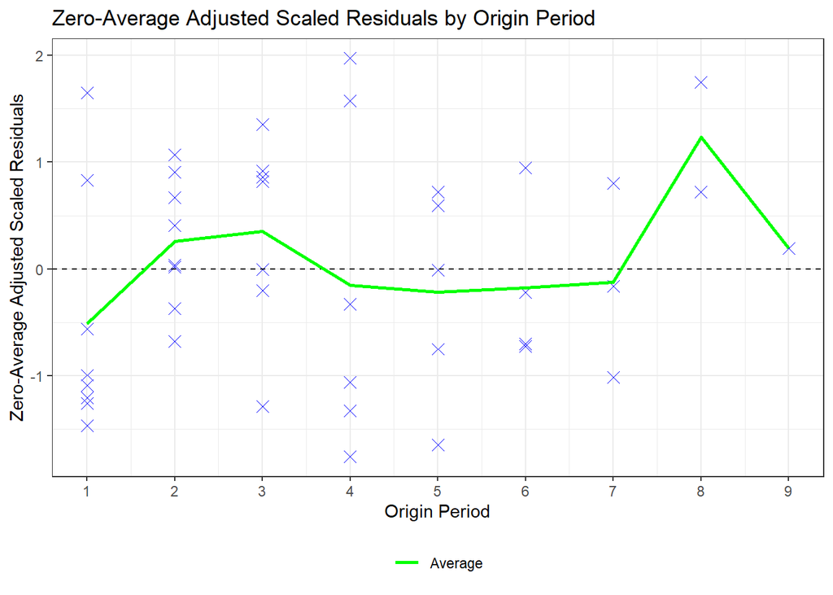

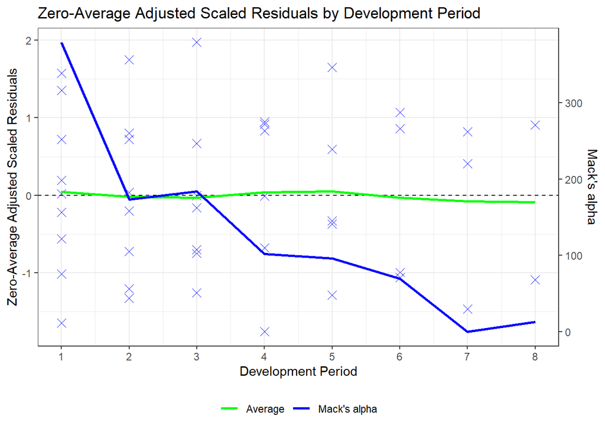

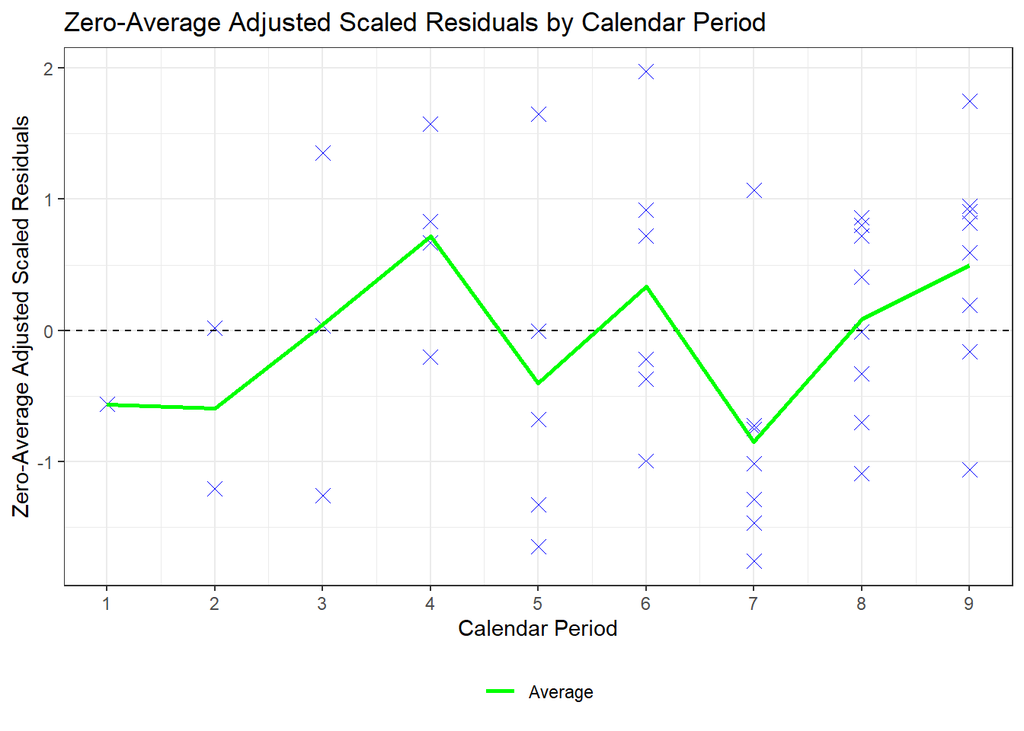

```r
# Residuals graphs associated with bootstrap method
#plotResiduals(Bstrap_Result$Resids, resid_type="adjunscaledresids", bstrap_method=method)
plotResiduals(Bstrap_Result$Resids, resid_type="zeroavgscaledresids", bstrap_method=method)
```

### Bootstrap results: Histogram and reserve development (fan) graphs:

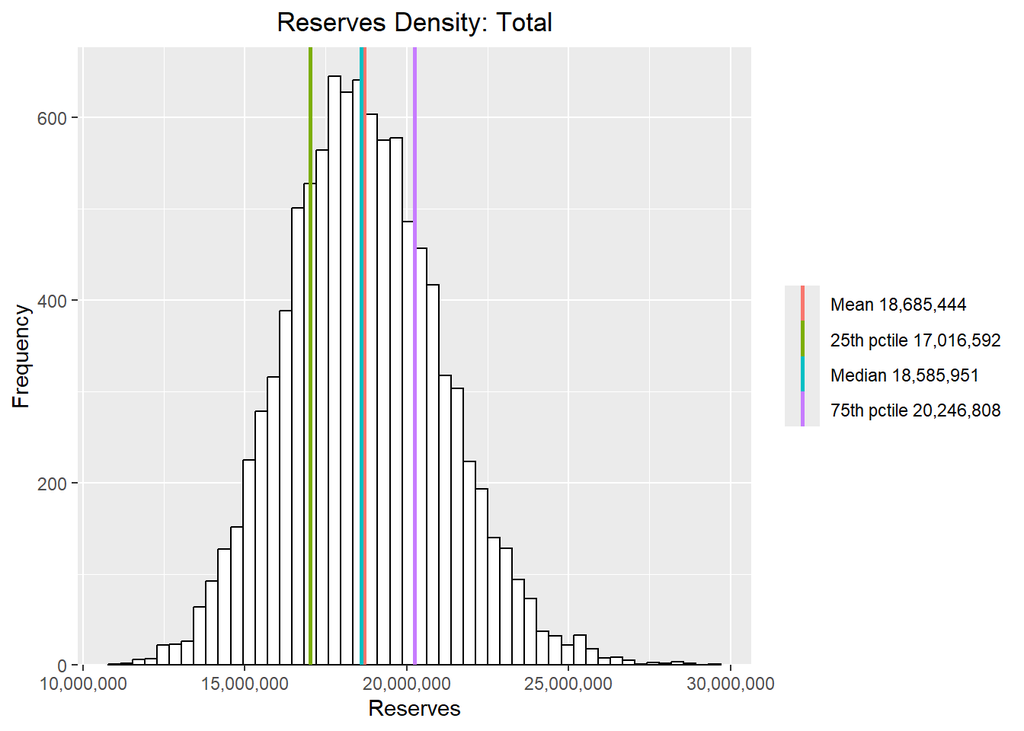

```r
# Histograms - Undiscounted reserves
plotHistogram_Total(Bstrap_Result$TotalReserve)
```

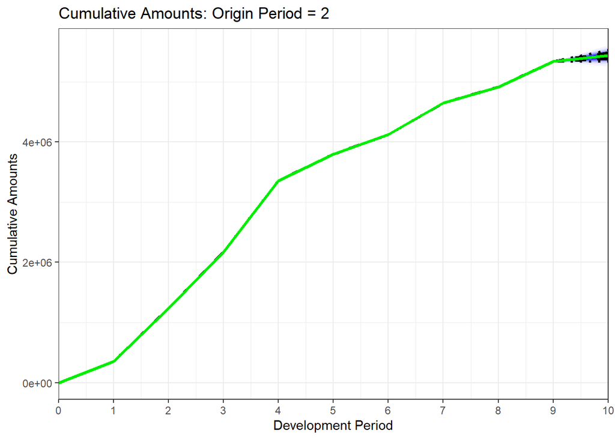

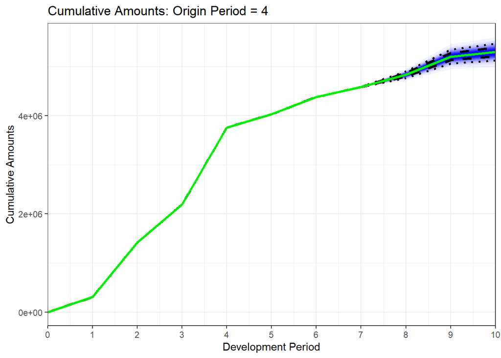

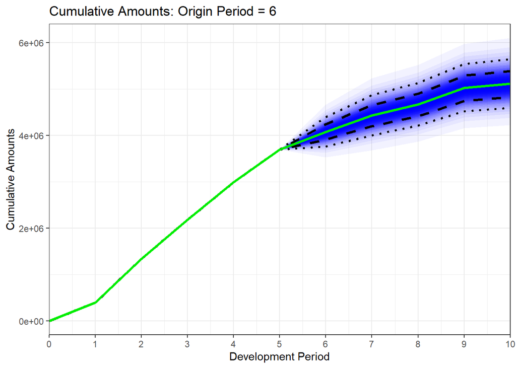

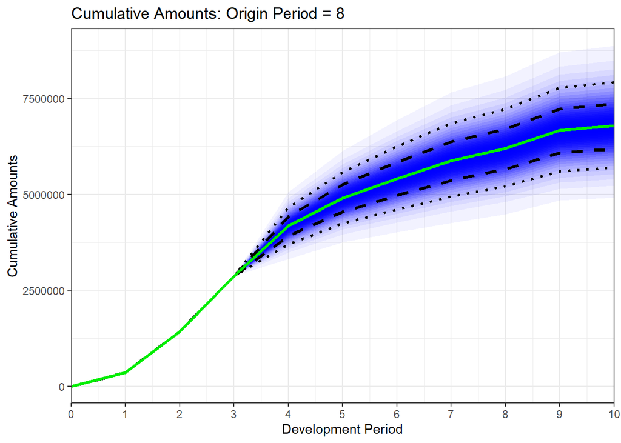

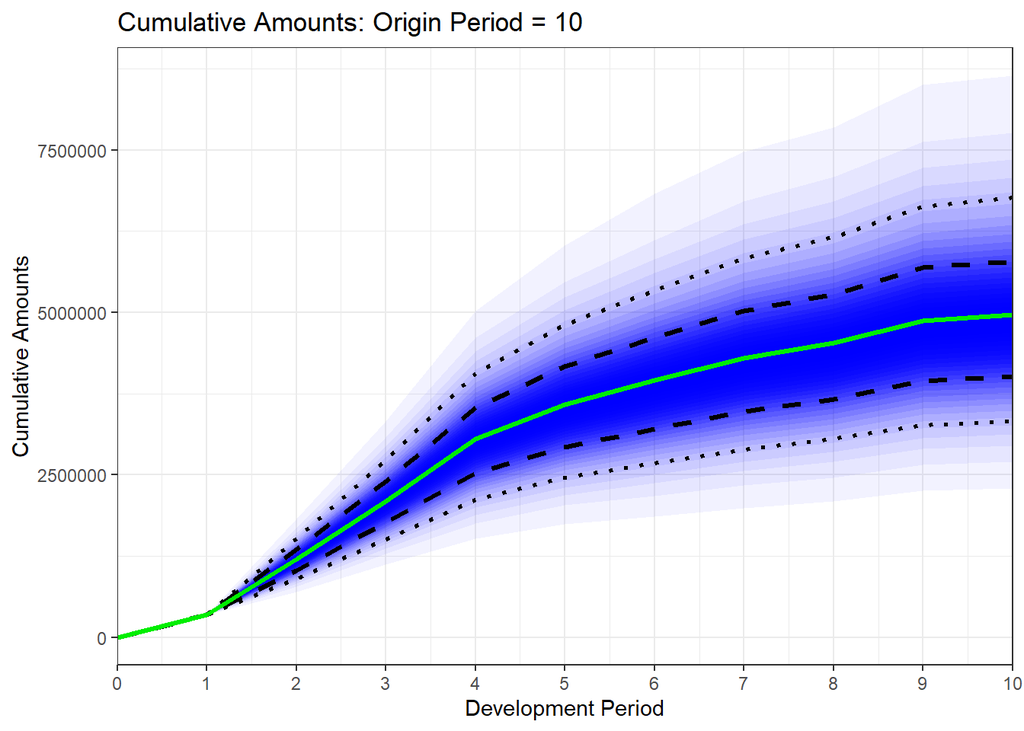

```r
#plotHistogram_by_yr(Bstrap_Result$Reserves)

# Development graphs
BStrap_Cumulatives <- Bstrap_Result$Cumulatives
for (yr in seq(2, ncol(BStrap_Cumulatives), by = 2)) {
  print(plotDevelopmentGraph(BStrap_Cumulatives,yr))
}
```

### Table 1: Chain ladder factors and sqrtScale / Mack’s alpha parameters

```r
# Table 1 - Chain ladder factors and sqrtScale  / Mack's alpha parameters
if (method %in% c("Mack", "NegBinConstant", "NegBinNonConstant")) {
  params_by_DevPeriod <- rbind(round(c(Bstrap_Result$CL_facs,1),3), round(c(Bstrap_Result$Resids$sqrtScale, NA),1))
} else {
  params_by_DevPeriod <- rbind(round(c(Bstrap_Result$CL_facs,1),3), round(Bstrap_Result$Resids$sqrtScale,1))
}
dp_labels <- paste("DP", 1:length(Triangle), sep=" ")
dimnames(params_by_DevPeriod) <- list(c("Dev Factors", "sqrtScale"), dp_labels)
cat("Development factors and sqrtScale parameters\n")
```

```
## Development factors and sqrtScale parameters
```

```r
params_by_DevPeriod
```

```
##                DP 1    DP 2    DP 3    DP 4    DP 5   DP 6   DP 7   DP 8   DP 9 DP 10
## Dev Factors   3.491   1.747   1.457   1.174   1.104  1.086  1.054  1.077  1.018     1
## sqrtScale   400.400 194.300 204.900 123.200 117.200 90.500 21.100 33.900 21.100    NA
```

### Table 2: Analytic results for chain ladder model

```r
# Table 2 - Analytic results for chain ladder model
Analytic_RMSEPs <- Calc_RMSEPs(Triangle, method, Mask=Indicators)
CL_Res <- Analytic_RMSEPs$CL_Res
CL_Res_SD <- Analytic_RMSEPs$Res_SD
CL_Res_CoV <- safe_divide(CL_Res_SD, CL_Res)
CL_CDR_SD_1Yr <- Analytic_RMSEPs$CDR_SD_1Yr
CL_CDR_Ratio <- safe_divide(CL_CDR_SD_1Yr, abs(CL_Res))
Table_2 <- cbind(round(CL_Res), round(CL_Res_SD), round(100*CL_Res_CoV,1),round(CL_CDR_SD_1Yr), round(100*CL_CDR_Ratio,1))
dimnames(Table_2) <- list(c(1:length(Triangle), "Total"), c("CL Reserves", "Reserve SD", "Reserve CoV %", "CDR SD", "CDR SD Ratio %"))
names(dimnames(Table_2)) <- c("Year","Analytic")
Table_2
```

```
##        Analytic
## Year    CL Reserves Reserve SD Reserve CoV %  CDR SD CDR SD Ratio %
##   1               0          0           0.0       0            0.0
##   2           94634      75535          79.8   75535           79.8
##   3          469511     121699          25.9  105309           22.4
##   4          709638     133549          18.8   79846           11.3
##   5          984889     261406          26.5  235115           23.9
##   6         1419459     411010          29.0  318427           22.4
##   7         2177641     558317          25.6  361089           16.6
##   8         3920301     875328          22.3  629681           16.1
##   9         4278972     971258          22.7  588662           13.8
##   10        4625811    1363155          29.5 1029925           22.3
##   Total    18680856    2447095          13.1 1778968            9.5
```

### Table 3: RMSEPs for each future year

```r
# Table 3
# Analytic results for chain ladder model
# For Mack's assumptions, use Merz-Wuthrich (2014) The Full Picture, and the ChainLadder package
Table_3 <- round(Analytic_RMSEPs$CDR_SD)
if (method!="Mack") {message("Analytic CDR RMSEPs not available for ODP or NegBin models")}
Table_3
```

```
##           IBNR CDR(1)S.E. CDR(2)S.E. CDR(3)S.E. CDR(4)S.E. CDR(5)S.E. CDR(6)S.E. CDR(7)S.E. CDR(8)S.E. CDR(9)S.E. CDR(10)S.E. Mack.S.E.
## 1            0          0          0          0          0          0          0          0          0          0           0         0
## 2        94634      75535          0          0          0          0          0          0          0          0           0     75535
## 3       469511     105309      60996          0          0          0          0          0          0          0           0    121699
## 4       709638      79846      91093      56232          0          0          0          0          0          0           0    133549
## 5       984889     235115      60577      82068      51474          0          0          0          0          0           0    261406
## 6      1419459     318427     233859      57825      82433      51999          0          0          0          0           0    411010
## 7      2177641     361089     328989     243412      59162      85998      54343          0          0          0           0    558317
## 8      3920301     629681     391249     359352     266320      64443      94166      59533          0          0           0    875328
## 9      4278972     588662     554574     344763     318493     236576      56543      83645      52965          0           0    971258
## 10     4625811    1029925     538726     511118     317142     293978     218914      51661      77317      49055           0   1363155
## Total 18680856    1778968    1177727     885178     607736     428681     267503     128557      96764      49055           0   2447095
```

### ONE-YEAR VIEW AND BEYOND - Re-reserving using the “Actuary-in-the-box”

### Table 4: Simulation results summary

```r
## ONE-YEAR VIEW AND BEYOND - Re-reserving using "Actuary-in-the-box"
CDR_Result <- CDR_Full_Picture(Triangle, Bstrap_Result$Cumulatives, VAR_p=0.995, Mask=Indicators)

#Table 4 - Simulation results summary
Table_4 <- cbind(round(Bstrap_Result$Avg_Reserve), round(Bstrap_Result$SD_Reserve), round(100*Bstrap_Result$CoV_Reserve,1),
                 round(CDR_Result$SD_CDR[1,]), round(100*safe_divide(CDR_Result$SD_CDR[1,], Bstrap_Result$Avg_Reserve),1))
Table_4_Totals <- cbind(round(Bstrap_Result$Avg_TotalReserve), round(Bstrap_Result$SD_TotalReserve), round(100*Bstrap_Result$CoV_TotalReserve,1),
                        round(CDR_Result$SD_TotalCDR[1]), round(100*safe_divide(CDR_Result$SD_TotalCDR[1], Bstrap_Result$Avg_TotalReserve,1)))
Table_4 <- rbind(Table_4, Table_4_Totals)
dimnames(Table_4) <- list(c(1:length(Triangle), "Total"), c("Avg Reserves", "Bstrap SD", "Bstrap CoV %", "CDR SD", "CDR SD Ratio %"))
names(dimnames(Table_4)) <- c("Year","Simulated (Undiscounted)")
Table_4
```

```
##        Simulated (Undiscounted)
## Year    Avg Reserves Bstrap SD Bstrap CoV %  CDR SD CDR SD Ratio %
##   1                0         0          0.0       0            0.0
##   2            95895     75276         78.5   75276           78.5
##   3           470465    121072         25.7  104145           22.1
##   4           709017    134034         18.9   79554           11.2
##   5           988539    259402         26.2  233247           23.6
##   6          1420929    408874         28.8  314535           22.1
##   7          2180842    556265         25.5  362932           16.6
##   8          3926132    866657         22.1  626981           16.0
##   9          4273893    962498         22.5  584774           13.7
##   10         4619729   1352232         29.3 1008047           21.8
##   Total     18685444   2409473         12.9 1750050            9.0
```

### Table 5: Discounted simulation results summary, including summary statistics

```r
# Table 5 - Discounted Results
disc_rate <- 0.03 # discount rate
offset <- 0.5 # assume payments are made half-way through the year
Bstrap_Result_Disc_Res <- Bstrap_Disc_Reserves(Bstrap_Result$Cumulatives, disc_rate, offset)
Table_5 <- cbind(round(Bstrap_Result_Disc_Res$Avg_Disc_Res), round(Bstrap_Result_Disc_Res$SD_Disc_Res), round(100*Bstrap_Result_Disc_Res$CoV_Disc_Res,1))
Table_5_Totals <- cbind(round(Bstrap_Result_Disc_Res$Avg_Disc_TotalRes), round(Bstrap_Result_Disc_Res$SD_Disc_TotalRes), round(100*Bstrap_Result_Disc_Res$Cov_Disc_TotalRes,1))
Table_5 <- rbind(Table_5, Table_5_Totals)
dimnames(Table_5) <- list(c(1:length(Triangle), "Total"), c("Avg Reserves", "Bstrap SD", "Bstrap CoV %"))
names(dimnames(Table_5)) <- c("Year","Simulated (Undiscounted)")
Table_5
```

```
##        Simulated (Undiscounted)
## Year    Avg Reserves Bstrap SD Bstrap CoV %
##   1                0         0          0.0
##   2            94488     74172         78.5
##   3           460849    117945         25.6
##   4           682748    127700         18.7
##   5           941146    250748         26.6
##   6          1336689    391729         29.3
##   7          2035692    525277         25.8
##   8          3661682    810515         22.1
##   9          3951198    884834         22.4
##   10         4221493   1226007         29.0
##   Total     17385986   2211355         12.7
```

```r
# Show set of summary statistics from bootstrap results
ShowStats <- ShowSummaryStats(Bstrap_Result_Disc_Res, Output="Reserves")
```

```
## [1] "Simulation Summary Statistics - Reserves"
##                              OP.1    OP.2   OP.3    OP.4    OP.5    OP.6    OP.7    OP.8    OP.9    OP.10    Total
## Mean                            0   94488 460849  682748  941146 1336689 2035692 3661682 3951198  4221493 17385986
## Standard Deviation              0   74172 117945  127700  250748  391729  525277  810515  884834  1226007  2211355
## Coefficient of Variation (%)  0.0    78.5   25.6    18.7    26.6    29.3    25.8    22.1    22.4     29.0     12.7
## Minimum                         0 -175254  31909  170791   57455  -88243  393622  967003 1228871   679425 10282152
## 0.5th Percentile                0  -97464 166566  354455  311419  369017  835823 1733440 1839003  1596744 12068451
## 1st Percentile                  0  -80221 191782  387764  363191  479446  922796 1907519 2072718  1786826 12639255
## 5th Percentile                  0  -29411 267787  476619  531119  708029 1211591 2355594 2575468  2390248 13903299
## 10th Percentile                 0    -644 309641  519564  619631  841212 1373007 2637077 2852248  2732407 14621250
## 25th Percentile                 0   45839 378865  595167  768012 1063479 1671430 3101587 3328244  3355833 15858813
## 50th Percentile (Median)        0   94717 461197  683598  940823 1329198 2012556 3642198 3909235  4127252 17293970
## 75th Percentile                 0  144963 540667  769614 1110639 1595319 2381678 4191611 4525368  4974563 18817774
## 90th Percentile                 0  189025 612034  846605 1262705 1844519 2712989 4727096 5116361  5858633 20232767
## 95th Percentile                 0  215029 654836  893069 1353886 1994052 2934761 5043228 5463518  6390557 21154672
## 99th Percentile                 0  264297 736698  977300 1521549 2283292 3343456 5619293 6167560  7545580 23116136
## 99.5th Percentile               0  285216 769941 1013127 1594109 2393171 3482622 5827374 6425497  7968702 23719959
## Maximum                         0  393978 951479 1232655 1838243 3031426 4399042 6879751 7876700 10795855 27252177
```

### Histogram of total discounted reserves

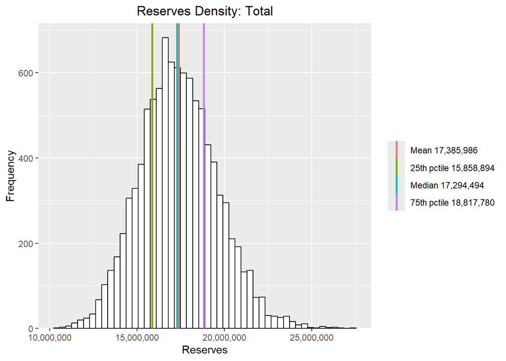

```r
# Histograms - Discounted reserves
plotHistogram_Total(Bstrap_Result_Disc_Res$TotalReserve)
```

```r
#plotHistogram_by_yr(Bstrap_Result_Disc_Res$Reserves)
```

### Table 6: SDs of simulated CDRs for each future year

```r
#Table 6 - SDs of simulated CDRs for each future year
Table_6 <- t(CDR_Result$SD_CDR)
Table_6 <- rbind(Table_6,CDR_Result$SD_TotalCDR)
Table_6_SS <- Table_6 * Table_6
Table_6_SS <- sqrt(apply(Table_6_SS, 1,sum))
Table_6 <- cbind(round(Table_6), round(Table_6_SS))
dimnames(Table_6) <- list(c(1:length(Triangle), "Total"), c(1:(length(Triangle)-1), "Sqrt SS"))
names(dimnames(Table_6)) <- c("Year","SD(CDR) by Future Year")
Table_6
```

```
##        SD(CDR) by Future Year
## Year          1       2      3      4      5      6      7     8     9 Sqrt SS
##   1           0       0      0      0      0      0      0     0     0       0
##   2       75276       0      0      0      0      0      0     0     0   75276
##   3      104145   61147      0      0      0      0      0     0     0  120769
##   4       79554   91172  56992      0      0      0      0     0     0  133751
##   5      233247   61221  81881  51656      0      0      0     0     0  259855
##   6      314535  237066  58333  82686  51586      0      0     0     0  409919
##   7      362932  330559 242930  59476  86224  54413      0     0     0  560300
##   8      626981  391485 357536 264685  63678  94604  59918     0     0  872267
##   9      584774  558060 342555 319390 233376  56682  83666 53768     0  969698
##   10    1008047  543153 510526 317026 293299 219722  51809 77608 49608 1348253
##   Total 1750050 1190948 890457 601383 425883 269622 128703 97168 49608 2432724
```

### Table 7: VaR @ 99.5% of simulated CDRs for each future year

```r
#Table 7 - VaR@99.5% of simulated CDRs for each future year
Table_7 <- t(CDR_Result$CDR_VAR)
Table_7 <- rbind(round(Table_7),round(CDR_Result$TotalCDR_VAR))
dimnames(Table_7) <- list(c(1:length(Triangle), "Total"), c(1:(length(Triangle)-1)))
names(dimnames(Table_7)) <- c("Year","VAR(CDR) @ 99.5% by Future Year")
Table_7
```

```
##        VAR(CDR) @ 99.5% by Future Year
## Year          1       2       3       4       5      6      7      8      9
##   1           0       0       0       0       0      0      0      0      0
##   2      193567       0       0       0       0      0      0      0      0
##   3      276083  154616       0       0       0      0      0      0      0
##   4      203592  236891  145381       0       0      0      0      0      0
##   5      606719  159788  210376  133429       0      0      0      0      0
##   6      824890  621853  150028  213135  131145      0      0      0      0
##   7      987445  904713  636636  155479  223163 147344      0      0      0
##   8     1702749 1036281  944388  720547  164357 249470 156701      0      0
##   9     1632524 1495018  905546  860842  617096 150164 216646 142111      0
##   10    2947024 1514362 1441479  858031  812154 600546 136724 213715 131213
##   Total 4826390 3160478 2358322 1587685 1144618 707936 332310 262409 131213
```

## Solvency II Cost-of-Capital Risk Margins

### Table 8: Cost-of-Capital Risk Margin

```r
#
# Solvency II Cost-of-Capital Risk Margins
#
# All costs-of-Capital assumed to be in arrears and discounted a full year.
# (ie Offset=1 in CoC_RM function). Check Solvency II documentation.
#

#Table 8 - Cost-of-Capital Risk Margin
#RM_Initial_Capital <- 4867412 # the value used in the paper
CoC_rate <- 0.06
# Set initial capital
RM_Initial_Capital <- CDR_Result$TotalCDR_VAR[1]
# Caluclate discounted reserves at each future year (discounted back to that year)
Disc_Fut_Res <- Disc_Future_Reserves(Incrementals(Bstrap_Result$CL_Cumulatives), disc_rate, offset)
# Obtain "Capital Profile"
Disc_BE_Profile <- Capital_Profile(Disc_Fut_Res)
# Calculate cost-of-capital risk margin
Disc_RM_BE <- CoC_RM(RM_Initial_Capital, Disc_BE_Profile, CoC_rate, disc_rate, 1)

Table_8 <- cbind(round(Disc_Fut_Res), round(Disc_RM_BE$Capital), round(100*Disc_BE_Profile,1), round(Disc_RM_BE$CoC), round(Disc_RM_BE$Disc_CoC))
BE_basis_RM <- round(Disc_RM_BE$RM)
dimnames(Table_8) <- list(c(0:(length(Triangle)-2)), c("Disc Fut Res","Capital","Capital Profile %", "Cost of Capital", "Disc CoC"))
names(dimnames(Table_8)) <- c("Future Year","")
Table_8
```

```
##
## Future Year Disc Fut Res Capital Capital Profile % Cost of Capital Disc CoC
##           0     17381602 4826390             100.0          289583   281149
##           1     12598695 3498309              72.5          209899   197850
##           2      8735034 2425477              50.3          145529   133179
##           3      5818790 1615717              33.5           96943    86133
##           4      3834408 1064709              22.1           63883    55106
##           5      2364307  656503              13.6           39390    32989
##           6      1239956  344302               7.1           20658    16797
##           7       521786  144886               3.0            8693     6862
##           8        85285   23681               0.5            1421     1089
```

```r
names(BE_basis_RM) <- "Risk Margin (Best Estimate Basis)"
BE_basis_RM
```

```
## Risk Margin (Best Estimate Basis)
##                            811153
```

### Table 9: Risk Margins under different bases

```r
# Table 9 - Risk Margins under different bases
CDR_SD_Profile <- Capital_Profile(CDR_Result$SD_TotalCDR)
CDR_VAR_Profile <- Capital_Profile(CDR_Result$TotalCDR_VAR)
Disc_RM_SD <- CoC_RM(RM_Initial_Capital, CDR_SD_Profile, CoC_rate, disc_rate, 1)
Disc_RM_VAR <- CoC_RM(RM_Initial_Capital, CDR_VAR_Profile, CoC_rate, disc_rate, 1)
Table_9_RMs <- cbind(round(Disc_RM_BE$RM), round(Disc_RM_SD$RM), round(Disc_RM_VAR$RM))
Table_9 <- cbind(round(Disc_RM_BE$Capital), round(Disc_RM_SD$Capital), round(Disc_RM_VAR$Capital))
Table_9 <- rbind(Table_9, Table_9_RMs)
dimnames(Table_9) <- list(c(0:(length(Triangle)-2),"Risk Margin"), c("Best Estimate","CDR SD","CDR VaR @ 99.5%"))
names(dimnames(Table_9)) <- c("Future Year","Risk Margins under different bases")
Table_9
```

```
##              Risk Margins under different bases
## Future Year   Best Estimate  CDR SD CDR VaR @ 99.5%
##   0                 4826390 4826390         4826390
##   1                 3498309 3284464         3160478
##   2                 2425477 2455753         2358322
##   3                 1615717 1658530         1587685
##   4                 1064709 1174525         1144618
##   5                  656503  743579          707936
##   6                  344302  354945          332310
##   7                  144886  267977          262409
##   8                   23681  136812          131213
##   Risk Margin        811153  824614          803512
```

## IFRS 17 Risk Adjustments

### Table 10: Risk adjustments using risk measures applied to the distribution of discounted reserves

```r
#Table 10 - Risk adjustments using risk measures applied to distribution of discounted reserves
VAR_level <- 0.75
TVAR_level <- 0.4
PHT_param <- 1.85

DiscTotalReserve_VAR <- -VAR(-Bstrap_Result_Disc_Res$TotalReserve, (1-VAR_level))
DiscTotalReserve_TVAR <- TVAR(Bstrap_Result_Disc_Res$TotalReserve, TVAR_level)
DiscTotalReserve_PHT <- PHT(Bstrap_Result_Disc_Res$TotalReserve, PHT_param)
DiscTotalReserve_VAR_RM <- DiscTotalReserve_VAR - Bstrap_Result_Disc_Res$Avg_Disc_TotalRes
DiscTotalReserve_TVAR_RM <- DiscTotalReserve_TVAR - Bstrap_Result_Disc_Res$Avg_Disc_TotalRes
DiscTotalReserve_PHT_RM <- DiscTotalReserve_PHT - Bstrap_Result_Disc_Res$Avg_Disc_TotalRes
DiscTotalReserve_VAR_RM_ratio <- DiscTotalReserve_VAR_RM/Bstrap_Result_Disc_Res$Avg_Disc_TotalRes
DiscTotalReserve_TVAR_RM_ratio <- DiscTotalReserve_TVAR_RM/Bstrap_Result_Disc_Res$Avg_Disc_TotalRes
DiscTotalReserve_PHT_RM_ratio <- DiscTotalReserve_PHT_RM/Bstrap_Result_Disc_Res$Avg_Disc_TotalRes
Table_10_R1 <- cbind(round(100*VAR_level), round(100*TVAR_level), round(100*PHT_param))
Table_10_R2 <- cbind(round(DiscTotalReserve_VAR_RM), round(DiscTotalReserve_TVAR_RM), round(DiscTotalReserve_PHT_RM))
Table_10_R3 <- cbind(round(Bstrap_Result_Disc_Res$Avg_Disc_TotalRes), round(Bstrap_Result_Disc_Res$Avg_Disc_TotalRes), round(Bstrap_Result_Disc_Res$Avg_Disc_TotalRes))
Table_10_R4 <- cbind(round(DiscTotalReserve_VAR), round(DiscTotalReserve_TVAR), round(DiscTotalReserve_PHT))
Table_10_R5 <- cbind(round(100*DiscTotalReserve_VAR_RM_ratio,1), round(100*DiscTotalReserve_TVAR_RM_ratio,1), round(100*DiscTotalReserve_PHT_RM_ratio,1))
Table_10 <- rbind(Table_10_R1, Table_10_R2, Table_10_R3, Table_10_R4, Table_10_R5)
dimnames(Table_10) <- list(c("Risk tolerance %", "Risk adjustment", "Best estimate (disc)", "Total", "Risk adjustment %"),
                           c("Value at Risk", "Tail Value at Risk","Prop. Hazards Transform"))
Table_10
```

```
##                      Value at Risk Tail Value at Risk Prop. Hazards Transform
## Risk tolerance %              75.0               40.0                   185.0
## Risk adjustment          1431787.0          1399933.0               1446307.0
## Best estimate (disc)    17385986.0         17385986.0              17385986.0
## Total                   18817772.0         18785918.0              18832292.0
## Risk adjustment %              8.2                8.1                     8.3
```

### Table 11: Equivalent risk tolerance levels to give Risk Adjustment = Cost-of-Capital risk margin

```r
#Table 11 - Equivalent risk tolerance levels to give risk adjustment = Cost-of-Capital risk margin
RM <- BE_basis_RM
RM_ratio <- RM/Disc_Fut_Res[1]
AvgDiscTotalRes <- Bstrap_Result_Disc_Res$Avg_Disc_TotalRes
# Search for VAR, TVAR and PHT risk tolerance levels
target <- RM
VAR_level <- uniroot(function(p) -VAR(-Bstrap_Result_Disc_Res$TotalReserve,(1-p)) -
                       AvgDiscTotalRes - target, c(0.000001,1))
TVAR_level <- uniroot(function(p) TVAR(Bstrap_Result_Disc_Res$TotalReserve,p) -
                        AvgDiscTotalRes - target, c(0,0.999999))
PHT_level <- uniroot(function(p) PHT(Bstrap_Result_Disc_Res$TotalReserve,p) -
                       AvgDiscTotalRes -target, c(1,1000))

DiscTotalReserve_VAR <- -VAR(-Bstrap_Result_Disc_Res$TotalReserve, (1-VAR_level$root))
DiscTotalReserve_TVAR <- TVAR(Bstrap_Result_Disc_Res$TotalReserve, TVAR_level$root)
DiscTotalReserve_PHT <- PHT(Bstrap_Result_Disc_Res$TotalReserve, PHT_level$root)
DiscTotalReserve_VAR_RM <- DiscTotalReserve_VAR - AvgDiscTotalRes
DiscTotalReserve_TVAR_RM <- DiscTotalReserve_TVAR - AvgDiscTotalRes
DiscTotalReserve_PHT_RM <- DiscTotalReserve_PHT - AvgDiscTotalRes
DiscTotalReserve_VAR_RM_ratio <- DiscTotalReserve_VAR_RM/AvgDiscTotalRes
DiscTotalReserve_TVAR_RM_ratio <- DiscTotalReserve_TVAR_RM/AvgDiscTotalRes
DiscTotalReserve_PHT_RM_ratio <- DiscTotalReserve_PHT_RM/AvgDiscTotalRes

Table_11_R1 <- c(NA, sprintf("%1.2f%%", 100*VAR_level$root), sprintf("%1.2f%%", 100*TVAR_level$root),
                 sprintf("%1.0f%%",round(100*PHT_level$root)))
Table_11_R2 <- c(RM, DiscTotalReserve_VAR_RM, DiscTotalReserve_TVAR_RM, DiscTotalReserve_PHT_RM)
Table_11_R3 <- c(Disc_Fut_Res[1], rep(AvgDiscTotalRes, 3))
Table_11_R4 <- c((Disc_Fut_Res[1] + RM), DiscTotalReserve_VAR, DiscTotalReserve_TVAR, DiscTotalReserve_PHT)
Table_11_R5 <- c(RM_ratio, DiscTotalReserve_VAR_RM_ratio, DiscTotalReserve_TVAR_RM_ratio, DiscTotalReserve_PHT_RM_ratio)
Table_11 <- rbind(Table_11_R1, format(round(Table_11_R2), big.mark=","), format(round(Table_11_R3), big.mark=","),
                  format(round(Table_11_R4), big.mark=","), sprintf("%1.2f%%", 100*Table_11_R5))
dimnames(Table_11) <- list(c("Risk tolerance", "Risk adjustment", "Best estimate (disc)", "Total", "Risk adjustment %"),
                           c("Cost-of-Capital", "Value at Risk", "Tail Value at Risk","Prop. Hazards Transform"))
Table_11
```

```
##                      Cost-of-Capital Value at Risk Tail Value at Risk Prop. Hazards Transform
## Risk tolerance       NA              "65.70%"      "22.02%"           "144%"
## Risk adjustment      "811,153"       "811,262"     "811,047"          "811,154"
## Best estimate (disc) "17,381,602"    "17,385,986"  "17,385,986"       "17,385,986"
## Total                "18,192,755"    "18,197,248"  "18,197,033"       "18,197,140"
## Risk adjustment %    "4.67%"         "4.67%"       "4.66%"            "4.67%"
```

## Alternative bases for Solvency II Cost-of-Capital Risk Margins

### Table 12: Mean, SD and VaR of the discounted reserves (and SD of the undiscounted reserves) with associated CoC risk margins

```r
# Table 12 - Mean, SD and VaR of the discounted reserves (and SD of the undiscounted reserves) with CoC risk margins
Bstrap_Result_Disc <- Bstrap_Disc_Future_Reserves(Bstrap_Result$Cumulatives, disc_rate, offset)
Bstrap_Result_UnDisc <- Bstrap_Disc_Future_Reserves(Bstrap_Result$Cumulatives, 0, 0)
# Capital using VaR @ target and 99.5 percentile levels:
target1 <- CDR_Result$TotalCDR_VAR[1]
VAR_level_res <- uniroot(function(p) -VAR(-Bstrap_Result_Disc_Res$TotalReserve,(1-p)) -
                           Bstrap_Result_Disc_Res$Avg_Disc_TotalRes - target1, c(0.000001,1))
Disc_FutRes_VAR_root <- -apply(-Bstrap_Result_Disc$FutureReserves,2,VAR, p=(1-VAR_level_res$root)) - Bstrap_Result_Disc$Avg_Disc_Fut_Res
Disc_FutRes_VAR_995 <- -apply(-Bstrap_Result_Disc$FutureReserves,2,VAR, p=(1-0.995)) - Bstrap_Result_Disc$Avg_Disc_Fut_Res

#
RM_Initial_Capital_T12 <- Disc_FutRes_VAR_root[1]
Disc_AvgRes_RM <- CoC_RM(RM_Initial_Capital_T12, Capital_Profile(Bstrap_Result_Disc$Avg_Disc_Fut_Res), CoC_rate, disc_rate, 1)$RM
Disc_SDReS_RM <- CoC_RM(RM_Initial_Capital_T12, Capital_Profile(Bstrap_Result_Disc$SD_Disc_Fut_Res), CoC_rate, disc_rate, 1)$RM
UnDisc_SDReS_RM <- CoC_RM(RM_Initial_Capital_T12, Capital_Profile(Bstrap_Result_UnDisc$SD_Disc_Fut_Res), CoC_rate, disc_rate, 1)$RM
Disc_VARRes_RM_root <- CoC_RM(RM_Initial_Capital_T12, Capital_Profile(Disc_FutRes_VAR_root), CoC_rate, disc_rate, 1)$RM
# Using VaR@99.5% of discounted future reserves for initial capital and capital profile
Disc_VARRes_RM_995 <- CoC_RM(Disc_FutRes_VAR_995[1], Capital_Profile(Disc_FutRes_VAR_995), CoC_rate, disc_rate, 1)$RM

Table_12 <- cbind(round(Bstrap_Result_Disc$Avg_Disc_Fut_Res),round(Bstrap_Result_Disc$SD_Disc_Fut_Res),round(Bstrap_Result_UnDisc$SD_Disc_Fut_Res), round(Disc_FutRes_VAR_root),round(Disc_FutRes_VAR_995))
Table_12_RMs <- cbind(round(Disc_AvgRes_RM), round(Disc_SDReS_RM), round(UnDisc_SDReS_RM), round(Disc_VARRes_RM_root), round(Disc_VARRes_RM_995))
Table_12 <- rbind(Table_12, Table_12_RMs)
dimnames(Table_12) <- list(c(0:(length(Triangle)-2),"Risk Adjustment"),
        c("Avg(Disc Res)","SD(Disc Res)","SD(Undisc Res)",
          paste0("VaR(Disc Res)@", round(100*VAR_level_res$root,1), "%"), "VaR(Disc Res)@99.5%"))
names(dimnames(Table_12)) <- c("Future Year","Mean, SD, VaR of reserves with CoC risk adjustments")
Table_12
```

```
##                  Mean, SD, VaR of reserves with CoC risk adjustments
## Future Year       Avg(Disc Res) SD(Disc Res) SD(Undisc Res) VaR(Disc Res)@98.1% VaR(Disc Res)@99.5%
##   0                    17385986      2211355        2409473             4828268             6333941
##   1                    12598382      1873653        2016486             4119143             5316560
##   2                     8730605      1495733        1593319             3371240             4281860
##   3                     5820154      1086818        1149909             2470479             3186524
##   4                     3836150       779561         818510             1804646             2268147
##   5                     2367108       526769         549149             1217342             1554644
##   6                     1241757       324733         336321              744241              945550
##   7                      523077       197683         202259              462591              604905
##   8                       85733        74859          75974              170726              236907
##   Risk Adjustment        811394      1026882        1007200             1051671             1355816
```

### Table 13: CoC risk margins based on reverse sum of CDRs

```r
# Table 13 - CoC risk margins based on reverse sum of CDRs
c1 <- Table_3[nrow(Table_3),2:(ncol(Table_3)-2)]
c1 <- as.vector(c1, "numeric")
CDRRevSum_SD_MW <- rev(sqrt(cumsum(rev(c1*c1))))

CDRRevSum <- CDR_Rev_Sum(CDR_Result$TotalCDR)
CDRRevSum_SD <- CDRRevSum$SD_RevSum_CDR

target2 <- CDR_Result$TotalCDR_VAR[1]
VAR_level_cdr <- uniroot(function(p) -VAR(CDRRevSum$RevSum_CDR[1,], (1-p)) + CDRRevSum$Avg_RevSum_CDR[1]
                         - target2, c(0.000001 ,1))
CDRRevSum_VAR_root <- -apply(CDRRevSum$RevSum_CDR,1,VAR, p=(1-VAR_level_cdr$root)) + CDRRevSum$Avg_RevSum_CDR
CDRRevSum_VAR_995 <- -apply(CDRRevSum$RevSum_CDR,1,VAR, p=(1-0.995)) + CDRRevSum$Avg_RevSum_CDR
#
RM_Initial_Capital_T13 <- CDRRevSum_VAR_root[1]
CDRRevSum_SD_MW_RM <- CoC_RM(RM_Initial_Capital_T13, Capital_Profile(CDRRevSum_SD_MW), CoC_rate, disc_rate, 1)$RM
CDRRevSum_SD_RM <- CoC_RM(RM_Initial_Capital_T13, Capital_Profile(CDRRevSum_SD), CoC_rate, disc_rate, 1)$RM
CDRRevSum_VAR_RM_root <- CoC_RM(RM_Initial_Capital_T13, Capital_Profile(CDRRevSum_VAR_root), CoC_rate, disc_rate, 1)$RM
CDRRevSum_VAR_RM_995 <- CoC_RM(CDRRevSum_VAR_995[1], Capital_Profile(CDRRevSum_VAR_995), CoC_rate, disc_rate, 1)$RM

Table_13 <- cbind(round(CDRRevSum_SD_MW), round(CDRRevSum_SD), round(CDRRevSum_VAR_root), round(CDRRevSum_VAR_995))
Table_13_RMs <- cbind(round(CDRRevSum_SD_MW_RM), round(CDRRevSum_SD_RM), round(CDRRevSum_VAR_RM_root), round(CDRRevSum_VAR_RM_995))
Table_13 <- rbind(Table_13, Table_13_RMs)
dimnames(Table_13) <- list(c(0:(length(Triangle)-2),"Risk Adjustment"),
                           c("MW RMSEP","SD(Simulated)",paste0("VaR @ ", round(100*VAR_level_cdr$root,1),"%"),"VaR @ 99.5%"))
names(dimnames(Table_13)) <- c("Future Year","Risk adjustments based on Reverse sum of CDRs")
Table_13
```

```
##                  Risk adjustments based on Reverse sum of CDRs
## Future Year       MW RMSEP SD(Simulated) VaR @ 97.2% VaR @ 99.5%
##   0                2447095       2409473     4829756     6903862
##   1                1680341       1678348     3320066     4513164
##   2                1198543       1207206     2409757     3294014
##   3                 808062        804774     1578587     2148988
##   4                 532562        532234     1053665     1462945
##   5                 315998        318057      621083      839473
##   6                 168216        167929      317300      427256
##   7                 108488        109678      212518      294495
##   8                  49055         49608       95511      131213
##   Risk Adjustment   800347        809137      801264     1111568
```

### Fig 1: Capital Profiles associated with Table 9 (including VaR @ target% of discounted outstanding reserves)

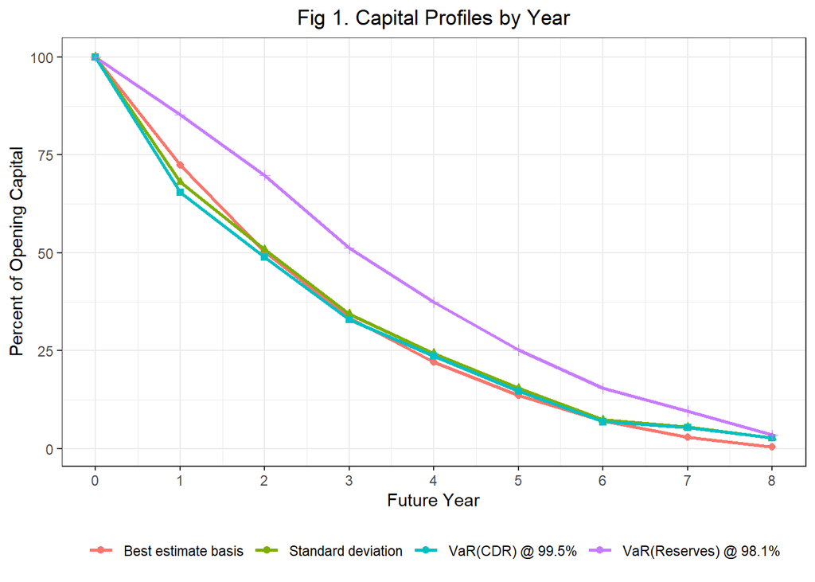

```r
# Fig 1 - Capital Profiles associated with Table 9 (including VaR @ target% of discounted outstanding reserves)
# put in alphabetical order for legend
a_profile <- Disc_BE_Profile
b_profile <- CDR_SD_Profile
c_profile <- CDR_VAR_Profile
d_profile <- Capital_Profile(Disc_FutRes_VAR_root)

Fig_1_Profiles <- tibble(date=c(0:(length(a_profile)-1)),a_profile, b_profile, c_profile, d_profile)
#Fig_1_Profiles # gives wide format. Long format needed for graph:
Fig_1_Profiles_long <- gather(Fig_1_Profiles, Method, Value, -"date")
Fig_1_theme <- theme(legend.title=element_blank(), plot.title = element_text(hjust=0.5), legend.position="bottom")
ggplot(Fig_1_Profiles_long, aes(x=date, y=Value*100, colour=Method, shape=Method)) +
  geom_line(size=1) + geom_point(size=1.8) +
  guides(shape=FALSE) +
  ggtitle("Fig 1. Capital Profiles by Year") +
  labs(y="Percent of Opening Capital",x="Future Year") +
  scale_color_hue(labels = c("Best estimate basis", "Standard deviation","VaR(CDR) @ 99.5%",
                             paste0("VaR(Reserves) @ ", round(100*VAR_level_res$root,1),"%"))) +
  scale_x_continuous(breaks=c(0:(length(Triangle)-2))) +
  theme_bw() + Fig_1_theme
```